# student performance final project

Bingyi Long/193000028

Dec 14 2022

On my honor, I have neither received nor given any unauthorized assistance on this homework. * SIGNED: [Bingyi Long]

Data Set Info:

This data approach student achievement in secondary education of two Portuguese schools. The data attributes include student grades, demographic, social and school related features) and it was collected by using school reports and questionnaires. Two datasets are provided regarding the performance in two distinct subjects: Mathematics (mat) and Portuguese language (por).

citation:

P. Cortez and A. Silva. Using Data Mining to Predict Secondary School Student Performance. In A. Brito and J. Teixeira Eds., Proceedings of 5th FUture BUsiness TEChnology Conference (FUBUTEC 2008) pp. 5-12, Porto, Portugal, April, 2008, EUROSIS, ISBN 978-9077381-39-7.

web link:

https://archive.ics.uci.edu/ml/datasets/Student+Performance

```r
library(ggplot2)
library(rstanarm)
library(bayesplot)
library(bayesrules)
library(tidyverse)
library(tidybayes)
library(broom.mixed)
```

```r
library(readr)
student_mat <- read_delim("student_mat.csv",
    delim = ";", escape_double = FALSE, col_types = cols(address = col_skip()),
    trim_ws = TRUE)

student_por <- read_delim("student_por.csv",
    delim = ";", escape_double = FALSE, col_types = cols(address = col_skip()),
    trim_ws = TRUE)


student_mat
```

| school | sex | age | famsize | Pstatus | Medu | Fedu | Mjob | Fjob | reason | guardian | traveltime | studytime | failures | schoolsup | famsup | paid | activities | nursery | higher | internet | romantic | famrel | freetime | goout | Dalc | Walc | health | absences | G1 | … |
| --- | --- | --- | --- | --- | --- | --- | --- | --- | --- | --- | --- | --- | --- | --- | --- | --- | --- | --- | --- | --- | --- | --- | --- | --- | --- | --- | --- | --- | --- | --- |
| GP | F | 18 | GT3 | A | 4 | 4 | at_home | teacher | course | mother | 2 | 2 | 0 | yes | no | no | no | yes | yes | no | no | 4 | 3 | 4 | 1 | 1 | 3 | 6 | 5 | … |
| GP | F | 17 | GT3 | T | 1 | 1 | at_home | other | course | father | 1 | 2 | 0 | no | yes | no | no | no | yes | yes | no | 5 | 3 | 3 | 1 | 1 | 3 | 4 | 5 | … |
| GP | F | 15 | LE3 | T | 1 | 1 | at_home | other | other | mother | 1 | 2 | 3 | yes | no | yes | no | yes | yes | yes | no | 4 | 3 | 2 | 2 | 3 | 3 | 10 | 7 | … |
| GP | F | 15 | GT3 | T | 4 | 2 | health | services | home | mother | 1 | 3 | 0 | no | yes | yes | yes | yes | yes | yes | yes | 3 | 2 | 2 | 1 | 1 | 5 | 2 | 15 | … |
| GP | F | 16 | GT3 | T | 3 | 3 | other | other | home | father | 1 | 2 | 0 | no | yes | yes | no | yes | yes | no | no | 4 | 3 | 2 | 1 | 2 | 5 | 4 | 6 | … |
| GP | M | 16 | LE3 | T | 4 | 3 | services | other | reputation | mother | 1 | 2 | 0 | no | yes | yes | yes | yes | yes | yes | no | 5 | 4 | 2 | 1 | 2 | 5 | 10 | 15 | … |
| GP | M | 16 | LE3 | T | 2 | 2 | other | other | home | mother | 1 | 2 | 0 | no | no | no | no | yes | yes | yes | no | 4 | 4 | 4 | 1 | 1 | 3 | 0 | 12 | … |
| GP | F | 17 | GT3 | A | 4 | 4 | other | teacher | home | mother | 2 | 2 | 0 | yes | yes | no | no | yes | yes | no | no | 4 | 1 | 4 | 1 | 1 | 1 | 6 | 6 | … |
| GP | M | 15 | LE3 | A | 3 | 2 | services | other | home | mother | 1 | 2 | 0 | no | yes | yes | no | yes | yes | yes | no | 4 | 2 | 2 | 1 | 1 | 1 | 0 | 16 | … |
| GP | M | 15 | GT3 | T | 3 | 4 | other | other | home | mother | 1 | 2 | 0 | no | yes | yes | yes | yes | yes | yes | no | 5 | 5 | 1 | 1 | 1 | 5 | 0 | 14 | … |

[output cut: 385 more lines]

```r
student_por
```

| school | sex | age | famsize | Pstatus | Medu | Fedu | Mjob | Fjob | reason | guardian | traveltime | studytime | failures | schoolsup | famsup | paid | activities | nursery | higher | internet | romantic | famrel | freetime | goout | Dalc | Walc | health | absences | G1 | … |
| --- | --- | --- | --- | --- | --- | --- | --- | --- | --- | --- | --- | --- | --- | --- | --- | --- | --- | --- | --- | --- | --- | --- | --- | --- | --- | --- | --- | --- | --- | --- |
| GP | F | 18 | GT3 | A | 4 | 4 | at_home | teacher | course | mother | 2 | 2 | 0 | yes | no | no | no | yes | yes | no | no | 4 | 3 | 4 | 1 | 1 | 3 | 4 | 0 | … |
| GP | F | 17 | GT3 | T | 1 | 1 | at_home | other | course | father | 1 | 2 | 0 | no | yes | no | no | no | yes | yes | no | 5 | 3 | 3 | 1 | 1 | 3 | 2 | 9 | … |
| GP | F | 15 | LE3 | T | 1 | 1 | at_home | other | other | mother | 1 | 2 | 0 | yes | no | no | no | yes | yes | yes | no | 4 | 3 | 2 | 2 | 3 | 3 | 6 | 12 | … |
| GP | F | 15 | GT3 | T | 4 | 2 | health | services | home | mother | 1 | 3 | 0 | no | yes | no | yes | yes | yes | yes | yes | 3 | 2 | 2 | 1 | 1 | 5 | 0 | 14 | … |
| GP | F | 16 | GT3 | T | 3 | 3 | other | other | home | father | 1 | 2 | 0 | no | yes | no | no | yes | yes | no | no | 4 | 3 | 2 | 1 | 2 | 5 | 0 | 11 | … |
| GP | M | 16 | LE3 | T | 4 | 3 | services | other | reputation | mother | 1 | 2 | 0 | no | yes | no | yes | yes | yes | yes | no | 5 | 4 | 2 | 1 | 2 | 5 | 6 | 12 | … |
| GP | M | 16 | LE3 | T | 2 | 2 | other | other | home | mother | 1 | 2 | 0 | no | no | no | no | yes | yes | yes | no | 4 | 4 | 4 | 1 | 1 | 3 | 0 | 13 | … |
| GP | F | 17 | GT3 | A | 4 | 4 | other | teacher | home | mother | 2 | 2 | 0 | yes | yes | no | no | yes | yes | no | no | 4 | 1 | 4 | 1 | 1 | 1 | 2 | 10 | … |
| GP | M | 15 | LE3 | A | 3 | 2 | services | other | home | mother | 1 | 2 | 0 | no | yes | no | no | yes | yes | yes | no | 4 | 2 | 2 | 1 | 1 | 1 | 0 | 15 | … |
| GP | M | 15 | GT3 | T | 3 | 4 | other | other | home | mother | 1 | 2 | 0 | no | yes | no | yes | yes | yes | yes | no | 5 | 5 | 1 | 1 | 1 | 5 | 0 | 12 | … |

[output cut: 639 more lines]

```r
NA
```

```r
student_mat<-student_mat %>%
  mutate(class="math")

student_por<-student_por %>%
  mutate(class="portuguese")

student_total <- rbind(student_mat, student_por)

student_total
```

| school | sex | age | famsize | Pstatus | Medu | Fedu | Mjob | Fjob | reason | guardian | traveltime | studytime | failures | schoolsup | famsup | paid | activities | nursery | higher | internet | romantic | famrel | freetime | goout | Dalc | Walc | health | absences | G1 | … |
| --- | --- | --- | --- | --- | --- | --- | --- | --- | --- | --- | --- | --- | --- | --- | --- | --- | --- | --- | --- | --- | --- | --- | --- | --- | --- | --- | --- | --- | --- | --- |
| GP | F | 18 | GT3 | A | 4 | 4 | at_home | teacher | course | mother | 2 | 2 | 0 | yes | no | no | no | yes | yes | no | no | 4 | 3 | 4 | 1 | 1 | 3 | 6 | 5 | … |
| GP | F | 17 | GT3 | T | 1 | 1 | at_home | other | course | father | 1 | 2 | 0 | no | yes | no | no | no | yes | yes | no | 5 | 3 | 3 | 1 | 1 | 3 | 4 | 5 | … |
| GP | F | 15 | LE3 | T | 1 | 1 | at_home | other | other | mother | 1 | 2 | 3 | yes | no | yes | no | yes | yes | yes | no | 4 | 3 | 2 | 2 | 3 | 3 | 10 | 7 | … |
| GP | F | 15 | GT3 | T | 4 | 2 | health | services | home | mother | 1 | 3 | 0 | no | yes | yes | yes | yes | yes | yes | yes | 3 | 2 | 2 | 1 | 1 | 5 | 2 | 15 | … |
| GP | F | 16 | GT3 | T | 3 | 3 | other | other | home | father | 1 | 2 | 0 | no | yes | yes | no | yes | yes | no | no | 4 | 3 | 2 | 1 | 2 | 5 | 4 | 6 | … |
| GP | M | 16 | LE3 | T | 4 | 3 | services | other | reputation | mother | 1 | 2 | 0 | no | yes | yes | yes | yes | yes | yes | no | 5 | 4 | 2 | 1 | 2 | 5 | 10 | 15 | … |
| GP | M | 16 | LE3 | T | 2 | 2 | other | other | home | mother | 1 | 2 | 0 | no | no | no | no | yes | yes | yes | no | 4 | 4 | 4 | 1 | 1 | 3 | 0 | 12 | … |
| GP | F | 17 | GT3 | A | 4 | 4 | other | teacher | home | mother | 2 | 2 | 0 | yes | yes | no | no | yes | yes | no | no | 4 | 1 | 4 | 1 | 1 | 1 | 6 | 6 | … |
| GP | M | 15 | LE3 | A | 3 | 2 | services | other | home | mother | 1 | 2 | 0 | no | yes | yes | no | yes | yes | yes | no | 4 | 2 | 2 | 1 | 1 | 1 | 0 | 16 | … |
| GP | M | 15 | GT3 | T | 3 | 4 | other | other | home | mother | 1 | 2 | 0 | no | yes | yes | yes | yes | yes | yes | no | 5 | 5 | 1 | 1 | 1 | 5 | 0 | 14 | … |

[output cut: 990 more lines]

```r
NA
```

```r
student<-student_total %>%
  select(G1, G2, G3, school, class, absences, studytime, Walc, Medu, Fedu)

student
```

| G1 | G2 | G3 | school | class | absences | studytime | Walc | Medu | Fedu |
| --- | --- | --- | --- | --- | --- | --- | --- | --- | --- |
| 5 | 6 | 6 | GP | math | 6 | 2 | 1 | 4 | 4 |
| 5 | 5 | 6 | GP | math | 4 | 2 | 1 | 1 | 1 |
| 7 | 8 | 10 | GP | math | 10 | 2 | 3 | 1 | 1 |
| 15 | 14 | 15 | GP | math | 2 | 3 | 1 | 4 | 2 |
| 6 | 10 | 10 | GP | math | 4 | 2 | 2 | 3 | 3 |
| 15 | 15 | 15 | GP | math | 10 | 2 | 2 | 4 | 3 |
| 12 | 12 | 11 | GP | math | 0 | 2 | 1 | 2 | 2 |
| 6 | 5 | 6 | GP | math | 6 | 2 | 1 | 4 | 4 |
| 16 | 18 | 19 | GP | math | 0 | 2 | 1 | 3 | 2 |
| 14 | 15 | 15 | GP | math | 0 | 2 | 1 | 3 | 4 |

[output cut: 990 more lines]

Prior Predictive Checks:

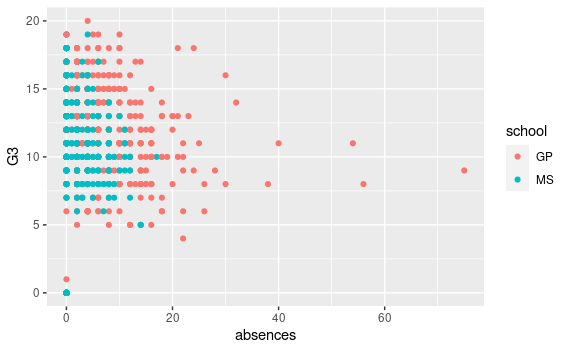

```r
ggplot(student, aes(y = G3, x = absences ,
                       color = school)) + geom_point()
```

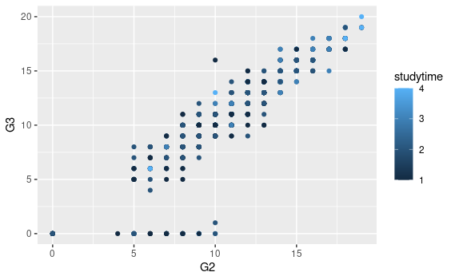

```r
ggplot(student, aes(y = G3, x = G2 ,
                       color = studytime)) + geom_point()
```

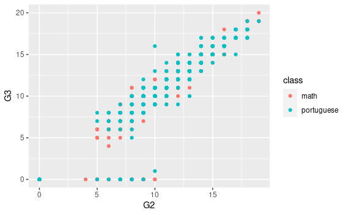

```r
ggplot(student, aes(y = G3, x = G2 ,
                       color = class)) + geom_point()
```

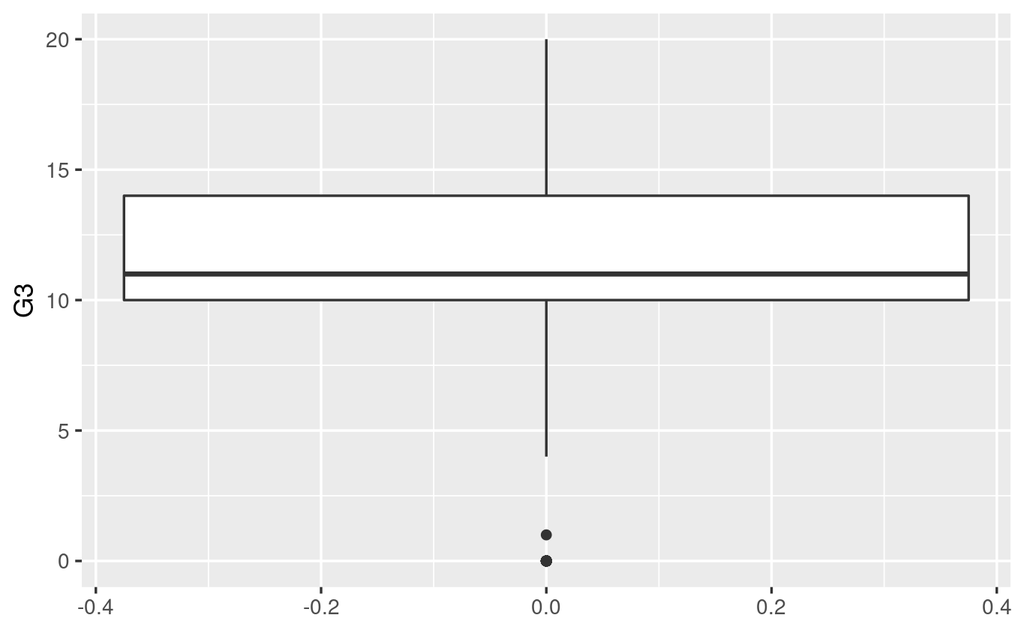

```r
ggplot(student, aes( y = G3)) +
  geom_boxplot()
```

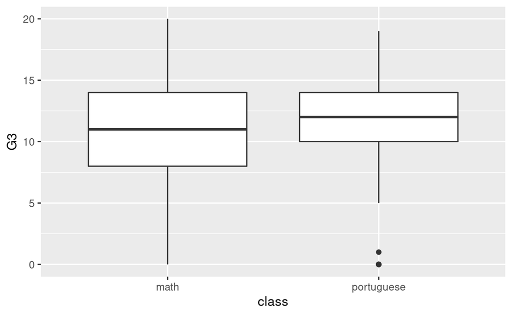

```r
ggplot(student, aes(x = class, y = G3)) +
  geom_boxplot()
```

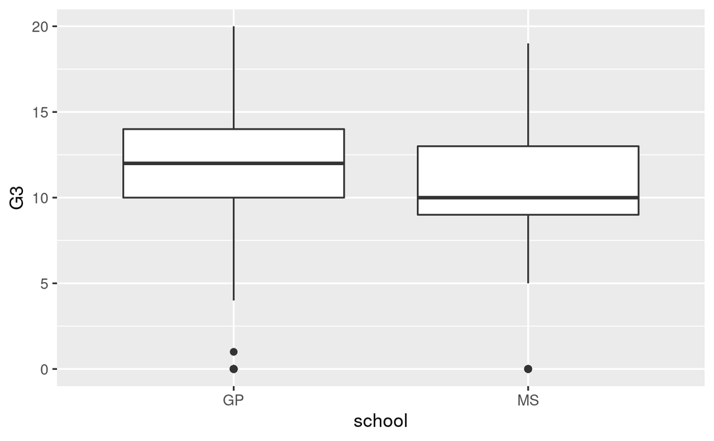

```r
ggplot(student, aes(x = school, y = G3)) +
  geom_boxplot()
```

First Model: simulate a posterior Normal regression model of `G3` by `G1` and `G2` G3: final year grade G1: 1st period grade G2: 2nd period grade.

use the average G3 is around 10-14 for “prior_intercept”

use the finding in a research paper “Student Ability Best Predicts Final Grade in a College Algebra Course,” which explored that indicators of students’ past performance and experience, including grade-point-average and the number of accumulated credit hours, best predict student success in this course for “prior” Thus. prior for G2+G1 should be strong positive relationship.

citation: O’Connell, K.A. et al. (2018) “Student ability best predicts final grade in a college algebra course,” Journal of Learning Analytics, 5(3). Available at: https://doi.org/10.18608/jla.2018.53.11.

```r
student_m1 <- stan_glm(
  G3 ~ G1+G2,
  data= student, family = gaussian,
  prior_intercept = normal(12, 1),
  prior = normal(2,1),
  prior_aux = exponential(1, autoscale = TRUE),
  chains = 4, iter = 5000*2, seed = 84735)
```

```r
prior_summary(student_m1)
```

```
Priors for model 'student_m1'
------
Intercept (after predictors centered)
 ~ normal(location = 12, scale = 1)

Coefficients
 ~ normal(location = [2,2], scale = [1,1])

Auxiliary (sigma)
  Specified prior:
    ~ exponential(rate = 1)
  Adjusted prior:
    ~ exponential(rate = 0.26)
------
See help('prior_summary.stanreg') for more details
```

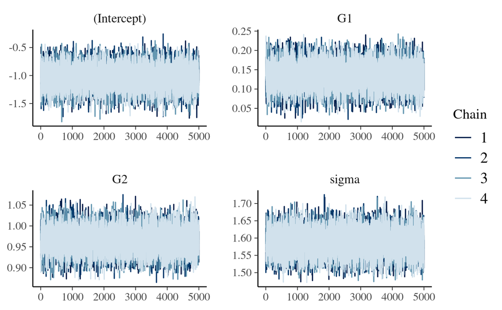

```r
mcmc_trace(student_m1, size = 0.5)
```

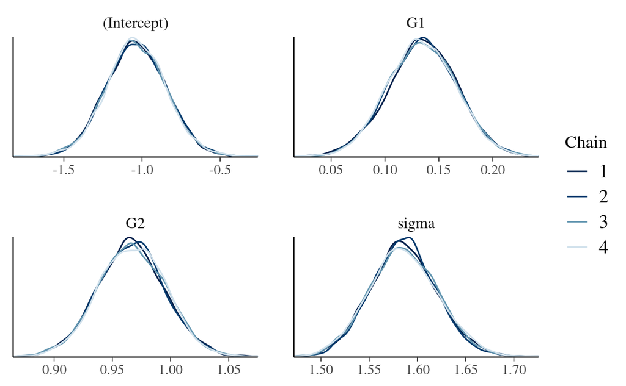

```r
mcmc_dens_overlay(student_m1)
```

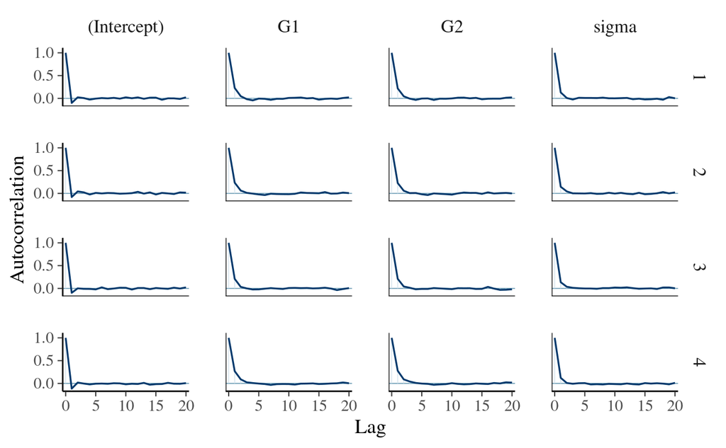

```r
mcmc_acf(student_m1)
```

```r
neff_ratio(student_m1)
```

```
(Intercept)          G1          G2       sigma
    1.16520     0.62605     0.62035     0.75580
```

```r
rhat(student_m1)
```

```
(Intercept)          G1          G2       sigma
  1.0001195   0.9999192   0.9999563   0.9999531
```

In visual examinations, trace-plots demonstrate randomness and seem like white noise,

parallel density plots have identical shape similar to each other,

and autocorrelation plot shows autocorrelation drops off quickly and is effectively 0 by Log10, so markov chain mixes quickly and mimics an independent sample.

In numerical examinations, all parameters’ R hat is close to 1, and it means chains perform almost the same and the result is reliable and appear repeatedly, and neff-ratio shows all parameters’ effective sample size ratios are all above 50%, which is good sign.

```r
tidy(student_m1, effects = c("fixed", "aux"),
     conf.int = TRUE, conf.level = 0.95)
```

| term | estimate | std.error | conf.low | conf.high |
| --- | --- | --- | --- | --- |
| (Intercept) | -1.0390327 | 0.19136053 | -1.41754172 | -0.6604876 |
| G1 | 0.1346581 | 0.03223248 | 0.07217294 | 0.1967659 |
| G2 | 0.9665876 | 0.02902231 | 0.90949932 | 1.0231870 |
| sigma | 1.5852838 | 0.03473765 | 1.51858737 | 1.6560824 |
| mean_PPD | 11.3435990 | 0.06900115 | 11.20874149 | 11.4806564 |

in the first regression model: Y=B0+B1X1+B2X2 G3= B0 + B1 G1 + B2 G2

Parameters Interpretation:

B1: first period grade coefficient, has a typical value of 0.135 and a 95% CI (0.072, 0.197) when G1 increases 1, G3 increases 0.135 on average.

B2: second period grade coefficient, has a typical value of 0.967 and a 95% CI (0.91, 1.023) when G2 increases 1, G3 increases 0.967 on average.

Because none of the CI include 0, these terms are significantly related to G3’s prediction.

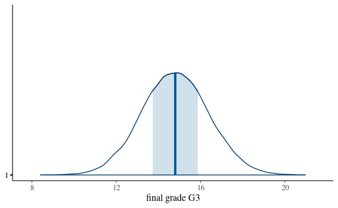

```r
set.seed(84735)

student_prediction <- posterior_predict(
  student_m1,
  newdata = data.frame(G1=10, G2=15))

mcmc_areas(student_prediction) +   xlab("final grade G3")
```

the posterior predictive model suggests for a student with G1=10, G2=15, their G3 is typically around 15.

Second Model:

simulate a posterior Normal regression model of `G3` by `G1` and `G2` with an interaction term between these two variables Because the second term grade is likely to depend on the first term grade.

G3:final year grade G1: 1st period grade G2: 2nd period grade.

use the same prior as first Model.

```r
student_interact <- stan_glm(
  G3 ~ G1+G2+G1:G2,
  data =  student, family = gaussian,
  prior_intercept = normal(12,1),
  prior = normal(2,1),
  prior_aux = exponential(1, autoscale = TRUE),
  chains = 4, iter = 5000*2,
  seed = 84735)
```

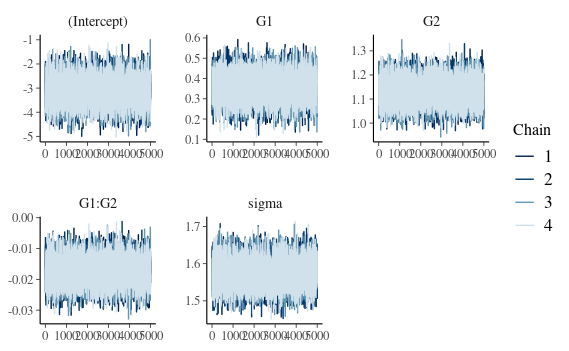

```r
mcmc_trace(student_interact, size = 0.5)
```

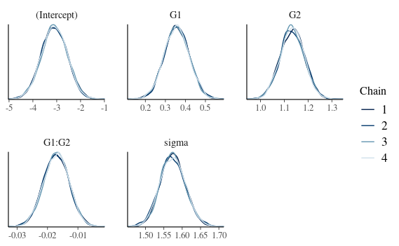

```r
mcmc_dens_overlay(student_interact)
```

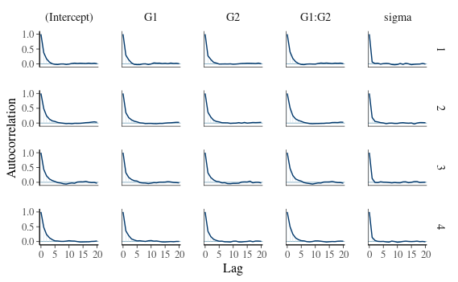

```r
mcmc_acf(student_interact)
```

```r
neff_ratio(student_interact)
```

```
(Intercept)          G1          G2       G1:G2       sigma
    0.37240     0.43685     0.44390     0.35900     0.72985
```

```r
rhat(student_interact)
```

```
(Intercept)          G1          G2       G1:G2       sigma
  1.0000597   1.0001187   0.9999738   1.0001434   1.0000958
```

Similar analysis as before. In short, trace-plots demonstrate randomness, parallel density plots have identical shape, autocorrelation plot tells markov chain mimics an independent sample.

all parameters’ R hat is close to 1, and neff-ratios are all above 35%, which is good.

```r
tidy(student_interact, effects = c("fixed", "aux"))
```

| term | estimate | std.error |
| --- | --- | --- |
| (Intercept) | -3.10309681 | 0.544820391 |
| G1 | 0.35672447 | 0.062648909 |
| G2 | 1.13345668 | 0.050843547 |
| G1:G2 | -0.01709222 | 0.004239404 |
| sigma | 1.57381351 | 0.034465595 |
| mean_PPD | 11.34465404 | 0.068310184 |

the tidy shows that coefficient of interaction-the relationship between G1 and G2 has a typical value -0.017 and within 2 se: -0.017+-(2*0.004)=(-0.025, -0.009), there is enough evidence that coefficient of interaction does not equal to 0, but it’s also a weak coefficient. The interaction term is still regarded useful, but it will be compared with other models later.

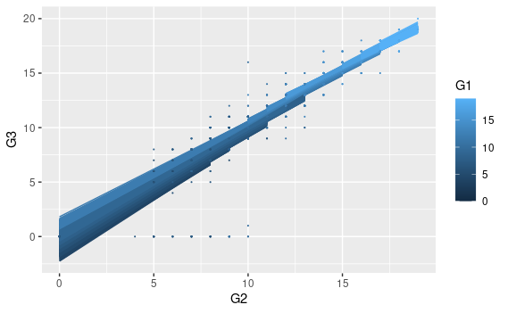

```r
student %>%
  add_fitted_draws(student_interact, n = 50) %>%
  ggplot(aes(x = G2, y = G3, color = G1)) +
  geom_line(aes(y=.value, group=paste(G1, .draw))) +
  geom_point(data = student, size = 0.1)
```

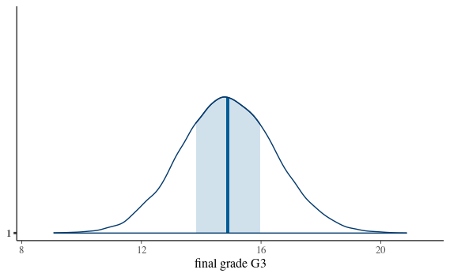

```r
set.seed(84735)

student_prediction <- posterior_predict(
  student_interact,
  newdata = data.frame(G1=10, G2=15))

mcmc_areas(student_prediction) +   xlab("final grade G3")
```

the posterior predictive model suggests for a student with G1=10, G2=15, their G3 is typically around 15.

Third Model: simulate a posterior Normal regression model of `G3` by other variables ‘Medu’,‘Fedu’, ‘absenses’, ‘Walc’, ‘studytime’

G3=B0+B1*Medu + B2*Fedu+ B3*absenses + B4*Walc+ B5*studytime

Medu - mother’s education (numeric: 0 - none, 1 - primary education (4th grade), 2 - 5th to 9th grade, 3 - secondary education or 4 - higher education) Fedu - father’s education (numeric: 0 - none, 1 - primary education (4th grade), 2 - 5th to 9th grade, 3 - secondary education or 4 - higher education) absenses - number of school absences (numeric: from 0 to 93) Walc - weekend alcohol consumption (numeric: from 1 - very low to 5 - very high) studytime - weekly study time (numeric: 1 - <2 hours, 2 - 2 to 5 hours, 3 - 5 to 10 hours, or 4 - >10 hours)

use the average G3 is around 10-14 for “prior_intercept”

For “Prior”:

use the finding in a research paper “Parenting Styles: The Impact on Student Achievement” which presents that Evidence was found to support the notion that parental education can have an indirect impact on children’s academic achievement in various cultures

In addition, the research paper “The association between levels of alcohol consumption and mental health problems and academic performance among young university students” discusses high levels of alcohol consumption are associated with poor academic performance and mental health outcomes among students.

citation: Brown, L. and Iyengar, S. (2008) “Parenting styles: The impact on student achievement,” Marriage & Family Review, 43(1-2), pp. 14–38. Available at: https://doi.org/10.1080/01494920802010140.

Tembo, C., Burns, S. and Kalembo, F. (2017) “The association between levels of alcohol consumption and mental health problems and academic performance among Young University Students,” PLOS ONE, 12(6). Available at: https://doi.org/10.1371/journal.pone.0178142.

```r
student_m2 <- stan_glm(
  G3 ~ Medu+Fedu+absences+Walc+studytime,
  data= student, family = gaussian,
  prior_intercept = normal(12, 1),
  prior = normal(5,2),
  prior_aux = exponential(1, autoscale = TRUE),
  chains = 4, iter = 5000*2, seed = 84735)
```

```r
prior_summary(student_m2)
```

```
Priors for model 'student_m2'
------
Intercept (after predictors centered)
 ~ normal(location = 12, scale = 1)

Coefficients
 ~ normal(location = [5,5,5,...], scale = [2,2,2,...])

Auxiliary (sigma)
  Specified prior:
    ~ exponential(rate = 1)
  Adjusted prior:
    ~ exponential(rate = 0.26)
------
See help('prior_summary.stanreg') for more details
```

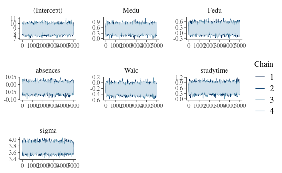

```r
mcmc_trace(student_m2, size = 0.5)
```

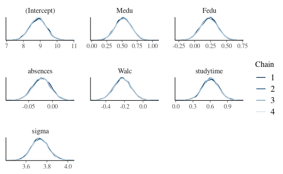

```r
mcmc_dens_overlay(student_m2)
```

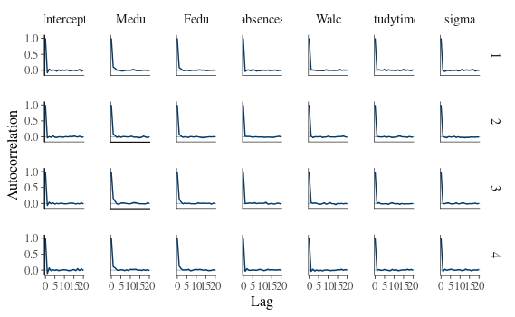

```r
mcmc_acf(student_m2)
```

```r
neff_ratio(student_m2)
```

```
(Intercept)        Medu        Fedu    absences        Walc
    1.07340     0.74790     0.76925     0.96930     0.98155
  studytime       sigma
    0.95470     1.01420
```

```r
rhat(student_m2)
```

```
(Intercept)        Medu        Fedu    absences        Walc
  0.9998642   0.9998457   0.9999124   1.0000610   0.9999605
  studytime       sigma
  0.9998734   0.9999175
```

Similar analysis as before. In short, trace-plots demonstrate randomness, parallel density plots have identical shape, autocorrelation plot tells markov chain mimics an independent sample.

all parameters’ R hat is close to 1, and neff-ratios are all above 70%, which is a good sign.

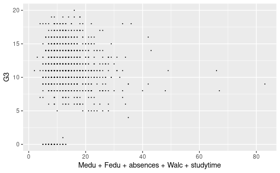

```r
student %>%
  add_fitted_draws(student_m2, n = 50) %>%
  ggplot(aes(x = Medu+ Fedu+ absences+ Walc+ studytime, y = G3)) +
  geom_point(data = student, size = 0.1)
```

```r
tidy(student_m2, effects = c("fixed", "aux"),
     conf.int = TRUE, conf.level = 0.95)
```

| term | estimate | std.error | conf.low | conf.high |
| --- | --- | --- | --- | --- |
| (Intercept) | 8.87015779 | 0.48869287 | 7.90600927 | 9.82772491 |
| Medu | 0.52126327 | 0.13387224 | 0.25233557 | 0.78307046 |
| Fedu | 0.22798757 | 0.13699899 | -0.03964111 | 0.49754398 |
| absences | -0.02254388 | 0.01900856 | -0.05939178 | 0.01509942 |
| Walc | -0.22239003 | 0.09208027 | -0.40717556 | -0.03919328 |
| studytime | 0.60680153 | 0.14335449 | 0.32102678 | 0.89346649 |
| sigma | 3.73466680 | 0.08220706 | 3.58003633 | 3.90266583 |
| mean_PPD | 11.35212584 | 0.16350013 | 11.03157181 | 11.67113438 |

in the third regression model: G3=B0+B1*Medu + B2*Fedu+ B3*absences + B4*Walc+ B5*studytime

Parameters Interpretation:

B1: Medu coefficient, has a typical value of 0.521 and a 95% CI (0.252, 0.783) when Medu increases 1 level, G3 increases 0.521 on average.

B2: Fedu coefficient, has a typical value of 0.228 and a 95% CI (-0.04, 0.5) when Fedu increases 1 level, G3 increases 0.228 on average, because 0 is contained in CI, it is not significantly useful in predicting G3.

B3: absences coefficient, has a typical value of -0.023 and a 95% CI (-0.06, 0.015), because contains 0, it is not significnatly useful in predicting G3.

B4: weekend alcohol use coefficient has a typical value of -0.222 and a 95% CI (-0.407, -0.039), so when weekend alcohol use increases 1 level, G3 typically decreases 0.222.

B5: study time coefficient has a typical value of 0.61 and a 95% CI (0.32, 0.89), so when study time increases 1 level, G3 typically increases 0.61.

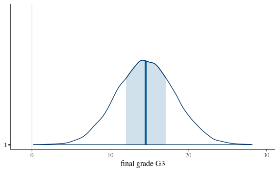

```r
set.seed(84735)

student_prediction <- posterior_predict(
  student_m2,
  newdata = data.frame(Medu=4, Fedu=4, absences=3, Walc=1, studytime=5))

mcmc_areas(student_prediction) +   xlab("final grade G3")
```

the posterior predictive model suggests for a student whose parents graduate from higher education, only has 3 absences, and slightly drink alcohol, and spend a lot time studying has a typical grade of 14.